# **Globalno zatopljenje**

**Globalno zatopljenje** ili globalno zagrijavanje je postupno zagrijavanje Zemljine površine i najnižih slojeva atmosfere uzrokovano učinkom staklenika, što dovodi i do globalnih promjena klime.

U posljednje vrijeme sve češće čujemo priče o globalnom zatopljenju. U ovoj zadaći ću analizirati temperaturne promjene zemljine klime kroz povijest sa naglaskom na posljednjih 200-injak godina od kada imamo službene podatke.

## **Ledena doba**

Iako pravo službeno mjerenje temperature kreće od kraja 19. stoljeća, znanstvenici pomoću sedimenata na dnu oceana, koraljnih grebena, jezgre ledenjaka, fosila i slično mogu utvrditi kakva je otprilike bila klima kroz povijest.

Smatra se da je u posljednje tri milijarde godina na zemlji bilo pet velikih ledenih doba.

| Ime ledenog doba | Vremenski period(u milijunima god.) |
| --- | --- |
| Quaternary | 2.58 - danas |
| Karoo | 360 - 260 |
| Andean-Saharan | 450 - 420 |
| Cryogenian | 850 - 635 |
| Huronian | 2400 - 2100 |

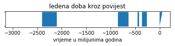

```python
import matplotlib.pyplot as plt
import numpy as np
x = np.array([-3000, -2401, -2400, -2100, -2099, -851, -850, -635, -634, -451, -450, -420, -419, -361, -360, -260, -259, -2,59 -2.58, 0.002])
y = np.array([0,0,1,1,0,0,1,1,0,0,1,1,0,0,1,1,0,0,1,1])

fig, ax = plt.subplots()
ax.plot = (x,y)
ax.fill_between(x,y)
ax.set(xlabel = 'vrijeme u milijunima godina', title = 'ledena doba kroz povijest')
ax.set_yticklabels([])
ax.set_aspect(300)
```

Iako smo i danas u ledenom dobu koje je započelo prije 2 milijuna i 580 tisuća godina, taj se period također može podijeliti na periode toplijih i hladnijih dijelova što vidimo na sljedećoj slici.

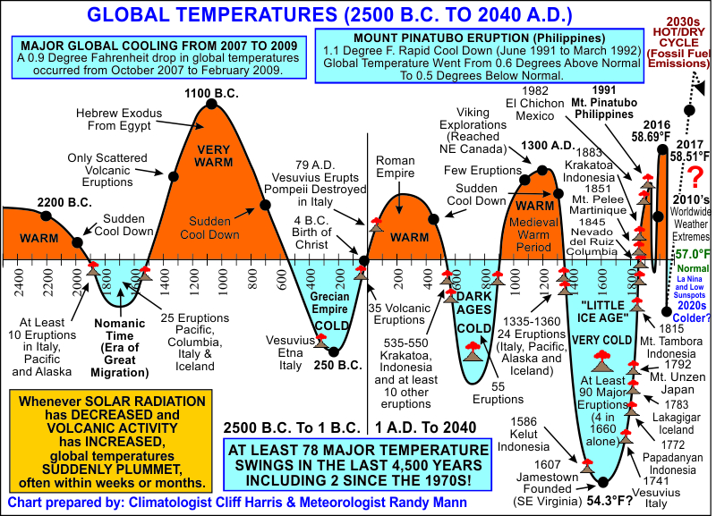

```python
from IPython.display import Image
Image('ledeno.jpg')
```

Posljednje "malo ledeno doba" bilo je od između 1300. i 1800. godine. Tijekom tog vremena bilo je malo sunčeve aktivnosti te mnogo vulkanskih erupcija. Nakon najveće zabilježene erupcije u ljudskoj povijesti 1815. godine, sljedeća godina u Europi i SAD-u u svakom mjesecu u godini je donijela snijeg. Nakon toga ulazimo u period zatopljenja te dolazimo do kraja 1800 godine kada imamo detaljne službene podatke koje ćemo analizirati.

## **Vremenske promjene od početka mjerenja**

```python
import pandas as pd
globalne = pd.read_csv('GlobalTemperatures.csv')
globalne.columns
```

```
Index(['dt', 'LandAverageTemperature', 'LandAverageTemperatureUncertainty',
       'LandMaxTemperature', 'LandMaxTemperatureUncertainty',
       'LandMinTemperature', 'LandMinTemperatureUncertainty',
       'LandAndOceanAverageTemperature',
       'LandAndOceanAverageTemperatureUncertainty'],
      dtype='object')
```

```python
globalne.head()
```

|  | dt | LandAverageTemperature | LandAverageTemperatureUncertainty | LandMaxTemperature | LandMaxTemperatureUncertainty | LandMinTemperature | LandMinTemperatureUncertainty | LandAndOceanAverageTemperature | LandAndOceanAverageTemperatureUncertainty |
| --- | --- | --- | --- | --- | --- | --- | --- | --- | --- |
| 0 | 1750-01-01 | 3.034 | 3.574 | NaN | NaN | NaN | NaN | NaN | NaN |
| 1 | 1750-02-01 | 3.083 | 3.702 | NaN | NaN | NaN | NaN | NaN | NaN |
| 2 | 1750-03-01 | 5.626 | 3.076 | NaN | NaN | NaN | NaN | NaN | NaN |
| 3 | 1750-04-01 | 8.490 | 2.451 | NaN | NaN | NaN | NaN | NaN | NaN |
| 4 | 1750-05-01 | 11.573 | 2.072 | NaN | NaN | NaN | NaN | NaN | NaN |

```python
len(globalne.index) / 12
```

```
266.0
```

```python
prosjek_po_godinama = {}

LandAverage = globalne['LandAverageTemperature'].tolist()

for i in range(266):
    prosjek = 0
    for j in range(12):
        prosjek = prosjek + LandAverage[i + j]
    prosjek_po_godinama[i+1750] = prosjek/12
```

[output not shown]

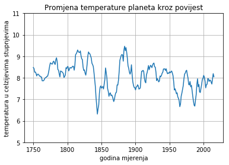

```python
LandAv, ax1 = plt.subplots()

ax1.plot(prosjek_po_godinama.keys(), prosjek_po_godinama.values())

ax1.set(xlabel='godina mjerenja', ylabel='temperatura u celzijevima stupnjevima',
       title='Promjena temperature planeta kroz povijest')
ax1.grid()
plt.ylim(5,11)
```

Vidimo kako zemljina površina nema neočekivan/značajan trend rasta ili pada.

Od 1850.godine imamo podatke za sve stupce pa ćemo pogledati maksimalnu i minimalnu temperaturu po godinama.

```python
prosjek_po_najvecoj = {}
prosjek_po_najmanjoj = {}

LandMax = globalne.dropna()['LandMaxTemperature'].tolist()
LandMin = globalne.dropna()['LandMinTemperature'].tolist()
```

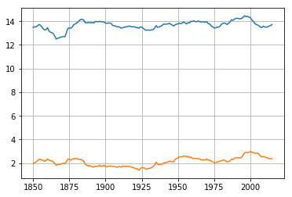

```python
for i in range(len(LandMax)//12):
    prosjek_min = 0
    prosjek_max = 0
    for j in range(12):
        prosjek_min = prosjek_min + LandMin[i + j]
        prosjek_max = prosjek_max + LandMax[i + j]
    prosjek_po_najvecoj[i+1850] = prosjek_max/12
    prosjek_po_najmanjoj[i+1850] = prosjek_min/12

LandMaxMin, ax2 = plt.subplots()
ax2.grid()
ax2.plot(prosjek_po_najvecoj.keys(), prosjek_po_najvecoj.values())
ax2.plot(prosjek_po_najmanjoj.keys(), prosjek_po_najmanjoj.values())
```

Niti kod maksimalnih i minimalnih temperatura nije zabilježen značajniji trend rasta/pada od početka mjerenja temperature.

## **Klima u Hrvatskoj**

```python
hrv = pd.read_csv('GlobalLandTemperaturesByCountry.csv')
hrv.sample(5)
```

|  | dt | AverageTemperature | AverageTemperatureUncertainty | Country |
| --- | --- | --- | --- | --- |
| 34945 | 1863-04-01 | 22.091 | 1.599 | Australia |
| 462730 | 1954-05-01 | 14.208 | 0.236 | Serbia |
| 61569 | 1855-11-01 | 23.545 | 0.958 | Belize |
| 270986 | 1862-12-01 | 9.181 | 1.460 | Jersey |
| 470326 | 2007-02-01 | 26.810 | 0.311 | Singapore |

```python
hrv[hrv.Country == 'Croatia'].head(), hrv[hrv.Country == 'Croatia'].tail()
```

```
(                dt  AverageTemperature  AverageTemperatureUncertainty  Country
 125541  1743-11-01               7.225                            2.3  Croatia
 125542  1743-12-01                 NaN                            NaN  Croatia
 125543  1744-01-01                 NaN                            NaN  Croatia
 125544  1744-02-01                 NaN                            NaN  Croatia
 125545  1744-03-01                 NaN                            NaN  Croatia,
                 dt  AverageTemperature  AverageTemperatureUncertainty  Country
 128775  2013-05-01              16.502                          0.311  Croatia
 128776  2013-06-01              20.418                          0.290  Croatia
 128777  2013-07-01              23.809                          0.416  Croatia
 128778  2013-08-01              23.560                          0.426  Croatia
 128779  2013-09-01                 NaN                            NaN  Croatia)
```

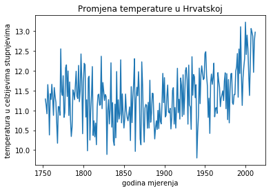

```python
import math
prosjek_hrv = {}
suma = 0
test = 'poz'
for i in range (125543,128771):
    #ne gledati godine u kojoj nedostaje podatak
    if (math.isnan(hrv.iloc[i,1])):
        test = 'neg'
    else:
        suma = suma + hrv.iloc[i,1]
    if (hrv.iloc[i,0][5:7] == '12'):
        if (test == 'poz'):
            prosjek_hrv[int(hrv.iloc[i,0][:4])] = suma/12
        suma = 0
        test = 'poz'

LandHrv, ax3 = plt.subplots()
ax3.set(xlabel='godina mjerenja', ylabel='temperatura u celzijevima stupnjevima',
       title='Promjena temperature u Hrvatskoj')
ax1.grid()
ax3.plot(prosjek_hrv.keys(), prosjek_hrv.values())
```

```python
prosjek_hrv?
```

[output not shown]

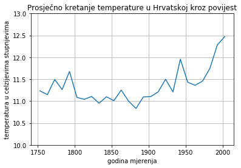

```python
#uzet ćemo prosječne podatke od svakih 10 godina da se dobije jasniji graf
prosjek_hrv_novi = {}
zbroj = 0

for i in range(0,260,10):
    for j in range(10):
        zbroj = zbroj + prosjek_hrv[1753 + i + j]
    prosjek_hrv_novi[1753 + i] = zbroj/10
    zbroj = 0

LandHrvProsjek, ax4 = plt.subplots()
ax4.plot(prosjek_hrv_novi.keys(), prosjek_hrv_novi.values())
ax4.grid()
ax4.set(xlabel='godina mjerenja', ylabel='temperatura u celzijevima stupnjevima',
       title='Prosječno kretanje temperature u Hrvatskoj kroz povijest')
ax1.grid()
plt.ylim(10,13)
```

Temperatura u Hrvtaskoj očito ima trend rasta. Stavit ćemo na isti graf i prosjek za prvi (najhladniji) mjesec te za sedmi (najtopliji) i usporediti da vidimo povećava li se temperatura više zbog toplijih ljeta ili toplije zime.

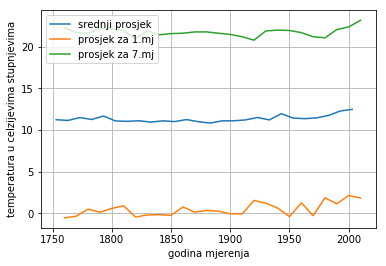

```python
prosjek_7 = {}
prosjek_1 = {}
suma1 = 0
suma7 = 0
pom = 0

for i in range (125543,128771,12):
    #ne gledati godine u kojoj nedostaje podatak
    if (not math.isnan(hrv.iloc[i,1]) and  not math.isnan(hrv.iloc[i+6,1])):
        pom = pom + 1
        suma1 = suma1 + hrv.iloc[i,1]
        suma7 = suma7 + hrv.iloc[i+6,1]
        if (pom == 10):
            prosjek_1[int(hrv.iloc[i,0][:4])] = suma1/10
            prosjek_7[int(hrv.iloc[i,0][:4])] = suma7/10
            suma1 = 0
            suma7 = 0
            pom = 0

LandHrv_1_7, ax5 = plt.subplots()
ax5.plot(prosjek_hrv_novi.keys(), prosjek_hrv_novi.values(), label = 'srednji prosjek')
ax5.plot(prosjek_1.keys(), prosjek_1.values(), label = 'prosjek za 1.mj')
ax5.plot(prosjek_7.keys(), prosjek_7.values(), label = 'prosjek za 7.mj')
ax5.set(xlabel='godina mjerenja', ylabel='temperatura u celzijevima stupnjevima')
ax5.legend(loc=2)
ax5.grid()
```

## **CO2 u atmosferi**

```python
from IPython.display import YouTubeVideo
YouTubeVideo('Rvi8UVa6iFE')
```

[video not shown]

```python
co2 = pd.read_json('global.json')
co2.head()
```

|  | Cement | Gas Flaring | Gas Fuel | Liquid Fuel | Per Capita | Solid Fuel | Total | Year |
| --- | --- | --- | --- | --- | --- | --- | --- | --- |
| 0 | 0 | 0 | 0 | 0 | NaN | 3 | 3 | 1751 |
| 1 | 0 | 0 | 0 | 0 | NaN | 3 | 3 | 1752 |
| 2 | 0 | 0 | 0 | 0 | NaN | 3 | 3 | 1753 |
| 3 | 0 | 0 | 0 | 0 | NaN | 3 | 3 | 1754 |
| 4 | 0 | 0 | 0 | 0 | NaN | 3 | 3 | 1755 |

[output not shown]

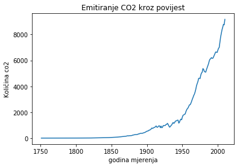

```python
co2_po_god = {}
for i in range (260):
    co2_po_god[co2.iloc[i,7]] = co2.iloc[i,6]

co2_graf, ax6 = plt.subplots()
ax6.plot(co2_po_god.keys(), co2_po_god.values())
ax6.set(xlabel='godina mjerenja', ylabel='Količina co2',
       title='Emitiranje CO2 kroz povijest')
```